# Projecting environmental variables: TESA simulation workshop

Daniel Duplisea

February 2021

## Goal

To outline three methods to consider how one could simulate future states of an environmental variable (E) based on past observations or models. The goal of such work would be to simulate future E to drive say a population dynamics model that has a functional E dependence to account for a mean change in E owing to climate change.

## Outline

Three methods:

1. Non-parametric resampling
- blocked sampling
- quantile sampling
2. Parametric resampling
- mean and variance shifted
3. Down-scaled climate projections
- an example using the Climate Atlas of Canada

## First, a data set

We will use the R package gslea to get data for the Gulf of St. Lawrence

```r
devtools::install_github("duplisea/gslea")
library(gslea)
```

This package gathers together lots of different data for broad ecosystem approach regions of the Gulf of St. Lawrence.

[figure not shown]

This package has search functions that we can use to find a variable. Here we search for “temp” as part of temperature and then we select the variable T250 (temperature at 250m) and we create a data.table with that variable for all years available for ecosystem approach region 2 (central Gulf). We also use the search function to create a text string describing the variable that can be used for axis label and titles:

```r
find.vars.f("temp")
```

```
##   [1] "Ann.coolingdd.high.RCP45"    "Ann.coolingdd.high.RCP85"
##   [3] "Ann.coolingdd.low.RCP45"     "Ann.coolingdd.low.RCP85"
##   [5] "Ann.coolingdd.med.RCP45"     "Ann.coolingdd.med.RCP85"
##   [7] "Ann.distr.coolingdd.mean.45" "Ann.distr.coolingdd.mean.85"
##   [9] "Ann.distr.coolingdd.sd.45"   "Ann.distr.coolingdd.sd.85"
##  [11] "Ann.distr.mean.fdd.mean.45"  "Ann.distr.mean.fdd.mean.85"
##  [13] "Ann.distr.mean.fdd.sd.45"    "Ann.distr.mean.fdd.sd.85"
##  [15] "Ann.distr.minus15.mean.45"   "Ann.distr.minus15.mean.85"
##  [17] "Ann.distr.minus15.sd.45"     "Ann.distr.minus15.sd.85"
##  [19] "Ann.mean.T.high.RCP45"       "Ann.mean.T.high.RCP85"
##  [21] "Ann.mean.T.low.RCP45"        "Ann.mean.T.low.RCP85"
##  [23] "Ann.mean.T.med.RCP45"        "Ann.mean.T.med.RCP85"
##  [25] "Ann.mean.fdd.high.RCP45"     "Ann.mean.fdd.high.RCP85"
##  [27] "Ann.mean.fdd.low.RCP45"      "Ann.mean.fdd.low.RCP85"
##  [29] "Ann.mean.fdd.med.RCP45"      "Ann.mean.fdd.med.RCP85"
```

[output cut: 36 more lines]

```r
var="T250"
vardesc=find.vars.f(var,T)$description
varval= EA.query.f(var,EARs=2, years=1800:2020)
```

Now let’s plot the data and look at how it is distributed

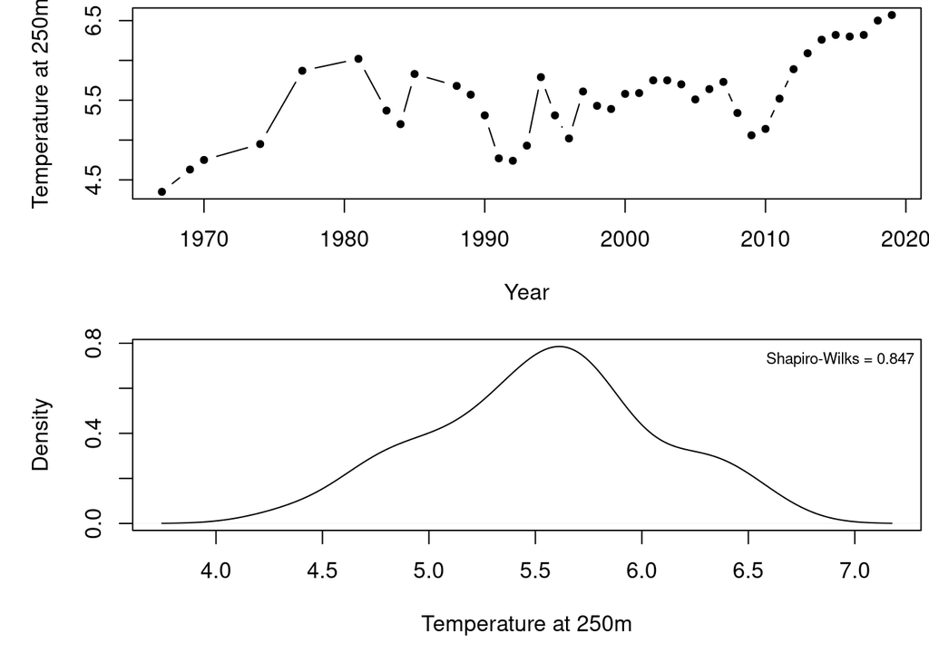

```r
par(mfcol=c(2,1),mar=c(5,5,.3,.3))
plot(varval$year, varval$value, type= "b", pch=20, xlab="Year", ylab=vardesc)
plot(density(varval$value),ylab="Density",xlab=vardesc, main="")
legend("topright",bty="n",cex=0.7, legend=paste("Shapiro-Wilks =",round(shapiro.test(varval$value)$p.value,3)))
```

The data looks pretty well normally distributed and you can see that since about 2010, the temperature is a steady rise to be at peak levels in the most recent years.

## Non-parametric sampling (empirical)

So using this dataset we can develop a scheme for sampling from the observations either in blocks or from quantiles of the distribution which could be hypothesised to represent a distribution for future climate.

So as a first example, say one wants to create future climate projection based on only the last 10 years of data and say 1000 samples for a projection

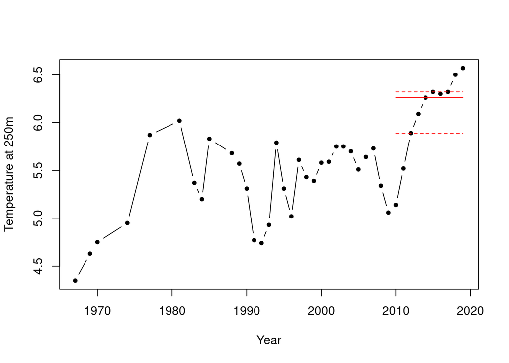

```r
plot(varval$year, varval$value, type= "b", pch=20, xlab="Year", ylab=vardesc)
Tsamps= sample(tail(varval$value,10),size=1000,replace=T)
lines(tail(varval$year,10),rep(median(Tsamps),10),col="red")
lines(tail(varval$year,10),rep(quantile(Tsamps,.75),10),col="red",lty=2)
lines(tail(varval$year,10),rep(quantile(Tsamps,.25),10),col="red",lty=2)
```

This shows the median and the 50% confidence interval on the median based on the resampling of the last 10 years of data. This sample could form the basis of a plausible near future climate scenario.

The problem with this kind of sampling is that it could be relatively conservative because it is constrained to observed values. This means that it may be too conservative to account for plausible future climate scenarios. It also is constrained to the observed values only while we might get a smoother and more plausble future probability density function using interpolation.

## parametric resampling

The non-parametric approach described above can be ‘smoothed’ by considering a parametric approach where we interpolate from the observed data set by fitting a distribution to those data and then draw from that distribution for future states in the E variable. Fitting the distribution is more hypothesis driven because there could be several different kinds of distribution that could be fitted. Log-normal would be the classic one and would fit with many datasets and in through use has the feel of being parsimonius. Log-normal may not be appropriate though in cases where say there are theoretical true upper limits. Also, we may wish to capture the possibility of “black swans” that could dominate what is happening in which case we may wish to use a heavier tailed distribution. Sean Anderson has done work on this.

Here is a simple example where we use the R library MASS to fit a distribution to data and then draw future samples from that distribution. The result of such a sampling after going through your population model to examine the impacts on a stock will have a smoother range of possible outcomes.

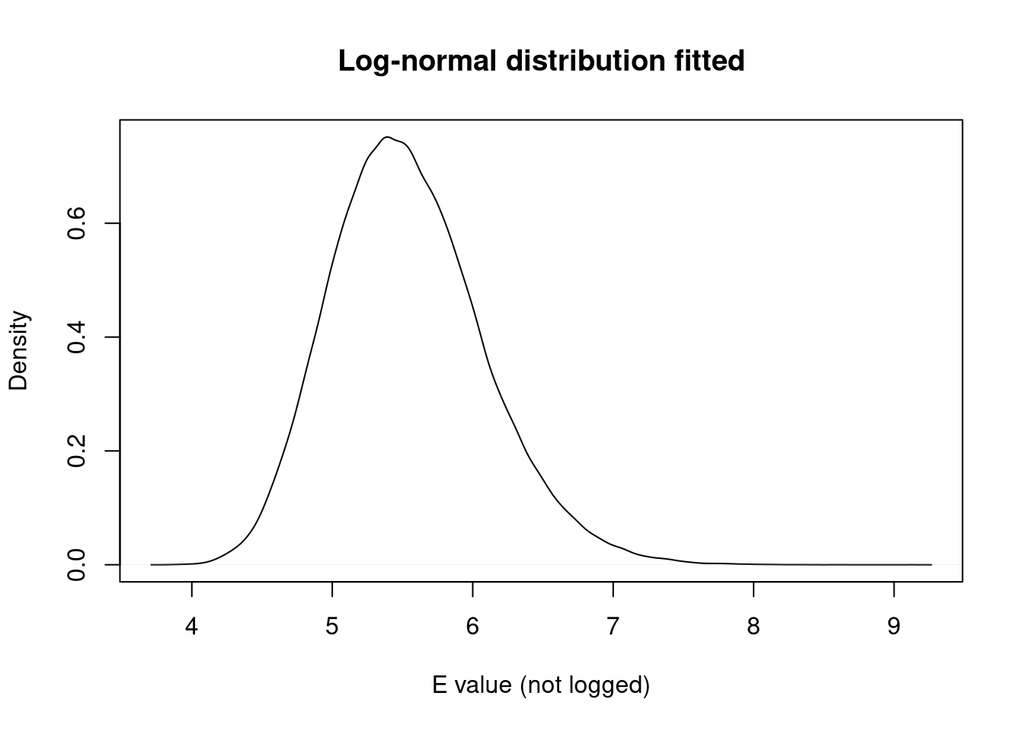

```r
library(MASS)
fittedLN= fitdistr(log(varval$value), densfun="lognormal")
LN.Esamples= rlnorm(100000, coef(fittedLN)[1], coef(fittedLN)[2])
plot(density(exp(LN.Esamples)),xlab="E value (not logged)", main="Log-normal distribution fitted")
```

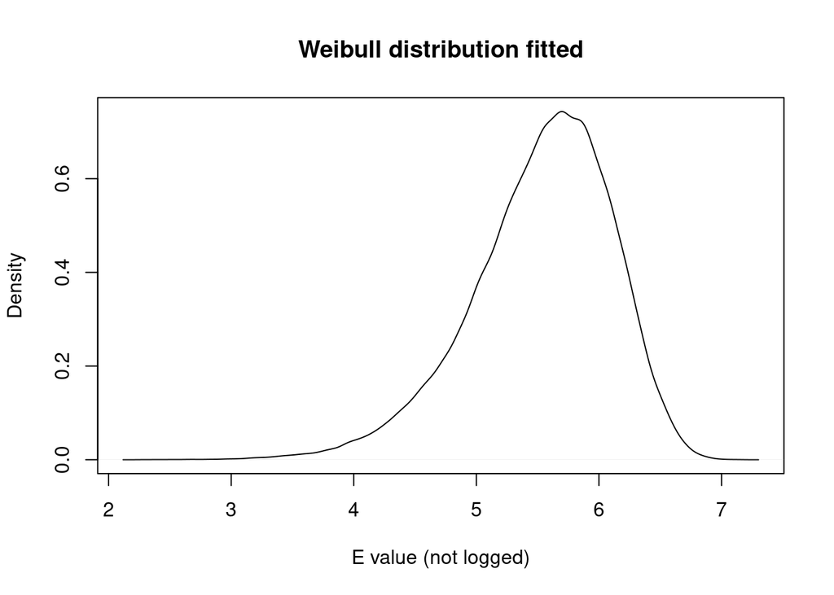

```r
# lets try a Weibull distribution which can have a fat tail and may give a higher probability to more extreme events
fittedWB= fitdistr(varval$value, densfun="weibull")
WB.Esamples= rweibull(100000, coef(fittedWB)[1], coef(fittedWB)[2])
plot(density(WB.Esamples),xlab="E value (not logged)", main="Weibull distribution fitted")
```

```r
# to my surprise it puts the tail on the lower side which is interesting
```

What is good about parametric distributions is that you can shift one of the parameters to immitate a plausible future state. For example, you can shift the mean up or down or change the variance. Climate change is projected to often shift the mean and increase the variance and this is pretty easy to do with most parametric distributions.

## Accounting for future climate using down-scaled GCM projections

What is possible to do is make a statistical model (e.g. a GLM) an oceanographic variable with the model output during the past (data) period and then go forward with this. This may not be ideal but at least it can be better than guessing.

The gslea package has integrated several of the atmospheric climate projection variables for the Gulf of St. Lawrence already so I will use that here.

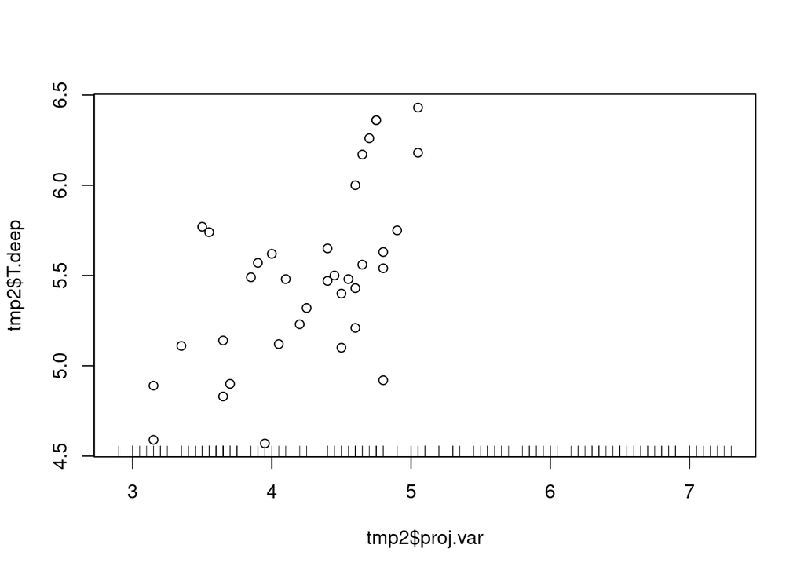

```r
 confint.f= function(x,ylow,yhigh,...){
    polygon(x = c(x, rev(x)), y = c(ylow,rev(yhigh)), border = NA,...)
}

  proj.var= "Ann.mean.T.med.RCP45"
  tmp= EA.query.f(c(proj.var,"T.deep"),1950:2100,2)
  tmp2= dcast(tmp, year~variable)
  names(tmp2)[3]= "proj.var"
  plot(tmp2$proj.var,tmp2$T.deep)
  rug(tmp2$proj.var)
```

```r
  pred.lm= lm(T.deep~proj.var,data=tmp2)
  summary(pred.lm)
```

```
##
## Call:
## lm(formula = T.deep ~ proj.var, data = tmp2)
##
## Residuals:
##      Min       1Q   Median       3Q      Max
## -0.86984 -0.24946 -0.09577  0.27351  0.69848
##
## Coefficients:
##             Estimate Std. Error t value Pr(>|t|)
## (Intercept)   3.1376     0.5317   5.901 1.16e-06 ***
## proj.var      0.5526     0.1238   4.465 8.39e-05 ***
## ---
## Signif. codes:  0 '***' 0.001 '**' 0.01 '*' 0.05 '.' 0.1 ' ' 1
##
## Residual standard error: 0.3933 on 34 degrees of freedom
##   (110 observations deleted due to missingness)
## Multiple R-squared:  0.3696, Adjusted R-squared:  0.3511
## F-statistic: 19.94 on 1 and 34 DF,  p-value: 8.387e-05
```

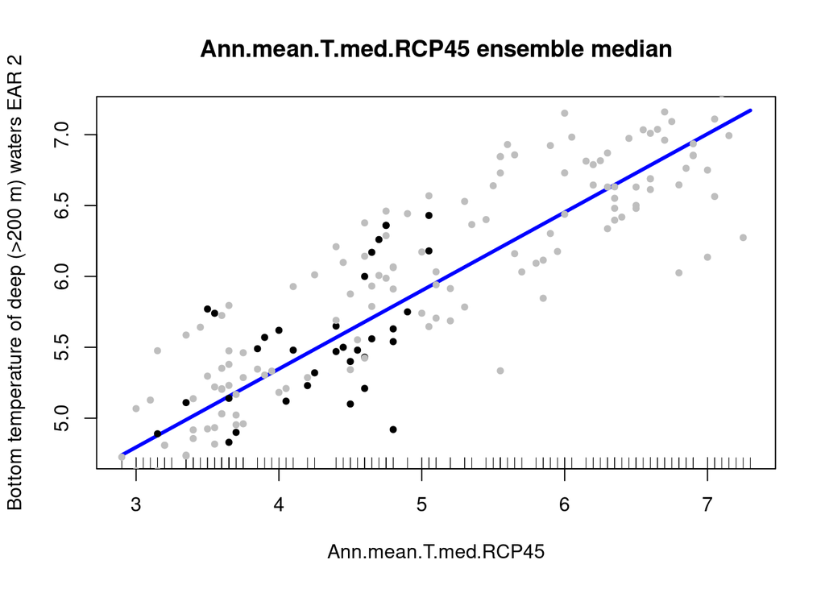

```r
  tmp2$T.deep.pred= predict(pred.lm,newdata=tmp2)
  plot(tmp2$proj.var,tmp2$T.deep.pred,type="l",col="blue",lwd=3,
       xlab=proj.var, ylab= "Bottom temperature of deep (>200 m) waters EAR 2")
  points(tmp2$proj.var,tmp2$T.deep,pch=20)
  rug(tmp2$proj.var)
  title(main=paste0(proj.var," ensemble median"))

  # so let's create future climate scenarios by calculating the deep water temperature based on the IPCC climate
  # projection and add a residual from the linear model for each to capture the variance in the fitted
  #relationship

  T.deep.pred= predict(pred.lm,newdata=tmp2)+sample(residuals(pred.lm), size=nrow(tmp2), replace=T)
  points(tmp2$proj.var, T.deep.pred, pch=20,col="grey")
```

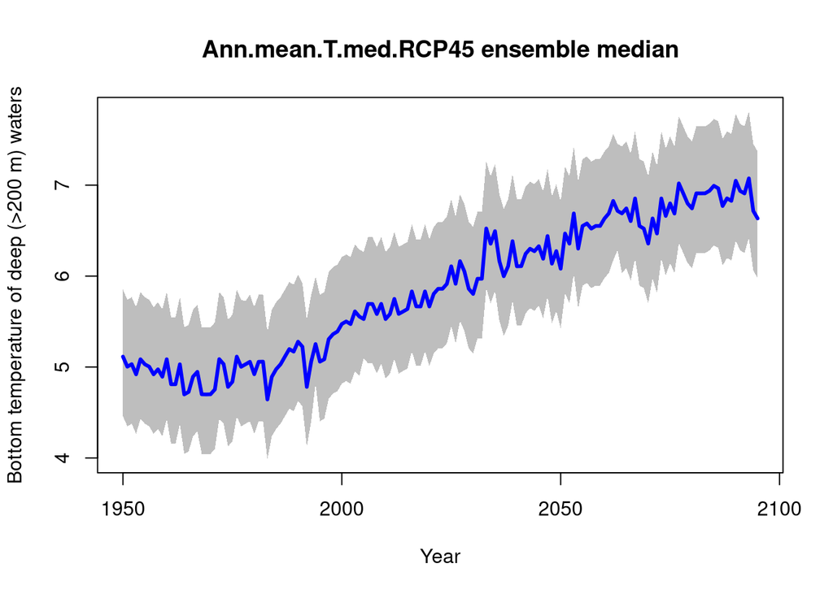

```r
  #setup a data.frame to output projections
  N=10000
  T.projections= matrix(nrow=nrow(tmp2),ncol=N)
  for (i in 1:N){
    T.projections[,i]= predict(pred.lm,newdata=tmp2)+sample(residuals(pred.lm), size=nrow(tmp2), replace=T)
  }

#In this case the variance carried forward in the future projections is simply the variance in the residuals of the fitted linear model. However one could fit differnt kinds of models any they could also use different GCM projections instead of, or more correctly, in addition to.

# So lets plot the whole thing with a 90% confidence interval
T.proj.quantiles= apply(T.projections,1,quantile,c(0.05, 0.5, 0.95))
ylims=range(T.proj.quantiles)
T.proj.quantiles= rbind(tmp2$year,T.proj.quantiles)

  plot(T.proj.quantiles[1,],T.proj.quantiles[3,],type="n",ylim=c(ylims[1],ylims[2]),
       xlab="Year", ylab= "Bottom temperature of deep (>200 m) waters")
  confint.f(T.proj.quantiles[1,],T.proj.quantiles[2,],T.proj.quantiles[4,],col="grey")
  lines(T.proj.quantiles[1,],T.proj.quantiles[3,],lwd=3, col="blue")
  title(main=paste0(proj.var," ensemble median"))
```